Partially observed functional data Hyunsung Kim 2021-01-25

# Simulation settings

> Lin, Z., & Wang, J. L. (2020). Mean and covariance estimation for functional snippets. Journal of the American Statistical Association, 1-13.
- 위 논문의 5장에서 $\text{cov I}, n=200, \delta=0.25, \text{SNR}=2$인 경우를 활용하였으며, $N=100$번 반복시행
- 기존 모형과 outlier를 추가하였을 때의 차이를 확인 (outlier 비율은 0.2라 가정)
- Variance $\sigma_X^2$과 covariance $C$의 estimation performance를 비교

## Methods for comparison

1. Yao, Müller, and Wang (2005) : `fdapace`
2. Liu and Müller (2009) : `fdapace`
3. Kraus (2015) : `Kraus(2015)/`
4. Zhang and Chen (2017) : `코드 못찾음`
5. Descary and Panaretos (2019) : `코드 못찾음`
6. Delaigle et al. (2020) : `Delaigle(2020)/` (matlab 코드)
7. Lin & Wang (2020) : [`mcfda`](https://github.com/linulysses/mcfda/)

최종적으로 **1. Yao, Müller, and Wang (2005)**과 **7. Lin & Wang (2020)**만을 비교함.

`Lin & Wang. (2020)` setting(functional snippets)에 적용가능한 방법은 1, 7번만 가능하며, `Kraus (2015)` 방법은 functional snippet case에서 사전 과정인 raw covariance 계산 자체가 불가능.

`Yao et al. (2005)`는 Principal analysis by conditional expecetation(PACE)를 제안하여 PCA와 curve reconstruction 관점에서의 비교를 하였고, `Liu & Müller (2009)`는 PACE를 확장하여 derivative estimation에 대한 방법론을 제시. (즉, 이 두 방법에서는 measurement erros $\sigma_0^2$를 같은 방식으로 estimate하는데, `Lin & Wang (2020)`에서 $\sigma_0^2$에 대한 RMSE를 비교한 것이 적절한 것인지 의문)

## Performance measure

- **Variance estimation**
  $$\begin{aligned}
  \text{RMISE} &= \sqrt{ \frac{1}{N} \sum_{i=1}^N \int_{\mathcal{T}} |\hat{\sigma}^2_X(t) - \sigma^2_X(t)|^2 dt} \\
  \text{RMSE} &= \sqrt{ \frac{1}{N} \sum_{i=1}^N \frac{1}{n(\mathcal{T})} \sum_{t \in \mathcal{T}} |\hat{\sigma}^2_X(t) - \sigma^2_X(t)|^2}
  \end{aligned}$$
- **Covariance estimation**
  $$\begin{aligned}
  \text{RMISE} &= \sqrt{ \frac{1}{N} \sum_{i=1}^N \int_{\mathcal{T}}\int_{\mathcal{T}} |\hat{C}(s,t) - C(s,t)|^2 dsdt} \\
  \text{RMSE} &= \sqrt{ \frac{1}{N} \sum_{i=1}^N \frac{1}{\{n(\mathcal{T})\}^2} \sum_{t \in \mathcal{T}} \sum_{s \in \mathcal{T}} |\hat{C}(s,t) - C(s,t)|^2}
  \end{aligned}$$

# Simulation results

## Original model

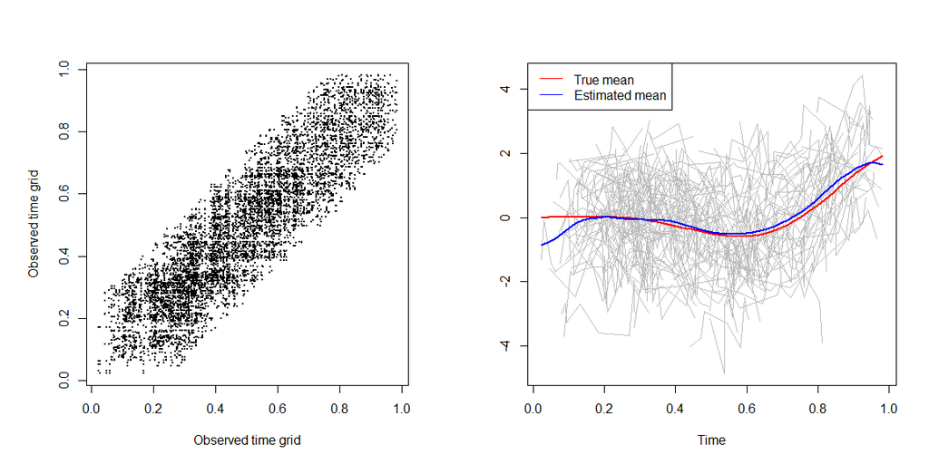

Figure 1. Design plot (Left) and smaple trajectories with mean curve (Right).

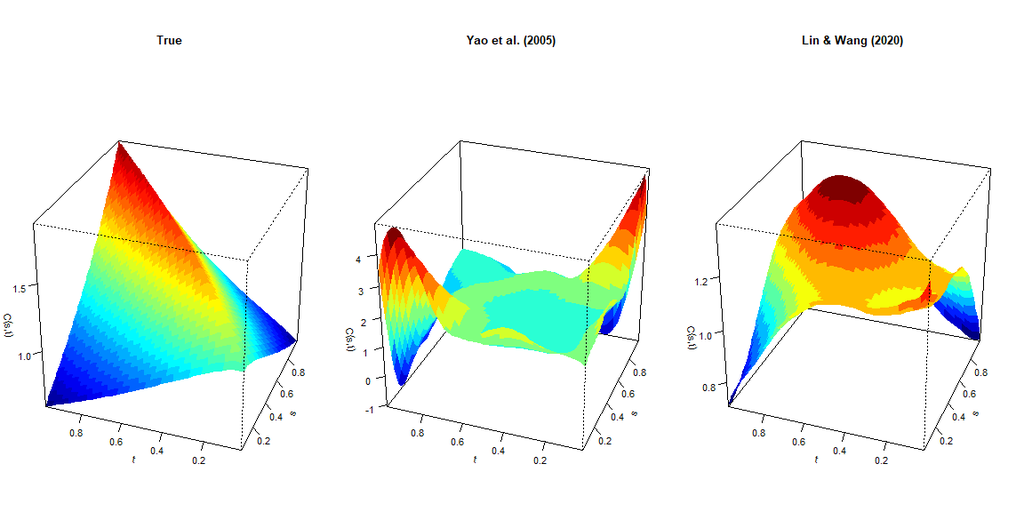

Figure 2. True covariance surface and estimated covariance surfaces.

Table 1. RMISE and RMSE for variance and covariance estimation.

|  | Variance Yao (2005) | Variance Lin (2020) | Covariance Yao (2005) | Covariance Lin (2020) |
| --- | --- | --- | --- | --- |
| RMISE | 0.812 | 0.760 | 1.008 | 0.487 |
| RMSE | 0.836 | 0.781 | 1.087 | 0.509 |

## Add outliers

### Outlier 1

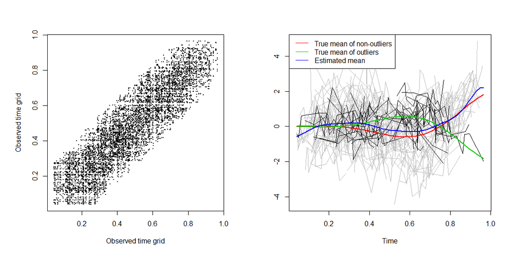

Figure 3. Design plot (Left) and smaple trajectories with mean curve (Right).

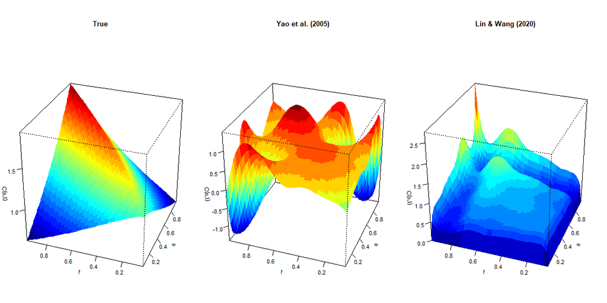

Figure 4. True covariance surface and estimated covariance surfaces.

Table 2. RMISE and RMSE for variance and covariance estimation.

|  | Variance Yao (2005) | Variance Lin (2020) | Covariance Yao (2005) | Covariance Lin (2020) |
| --- | --- | --- | --- | --- |
| RMISE | 0.818 | 0.743 | 1.128 | 0.486 |
| RMSE | 0.848 | 0.773 | 1.219 | 0.507 |